# SemiMech Flu Forecasting

## Introduction

In this vignette we are going to demonstrate how to use the semi-mechanistic model to forecast influenza hospitalizations. The model models seasons hierarchically, with a unique set of parameters for each season tied together through a prior distribution.

This model uses the fundamental semi-mech equation to model hospitalizations at time $t$ in season $s$ as,

$$h(t,s) = \theta(s) e^{f(t,s) - \phi(s) g(t,s)}$$
$$g(t,s) = \int_0^t e^{f(t',s)dt'}$$
$$f(t,s) = spline(t,s)$$

## Application to influenza hospitalization forecasting

First, we will download the data we need for forecasting influenza hospitalizations

```r
library(stringr)
setwd("../")
source('R/get_hhs.R')
hhs <- get_hhs()
```

Let’s plot Texas (TX) as our example state.

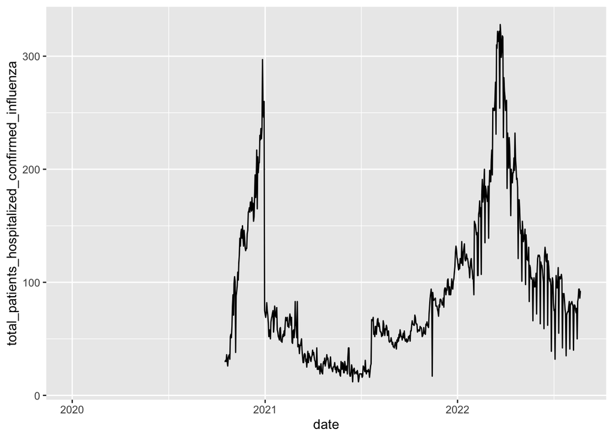

```r
library(ggplot2)
ggplot(hhs[hhs$state == "TX",],aes(x=date,y=total_patients_hospitalized_confirmed_influenza))+ geom_line()
```

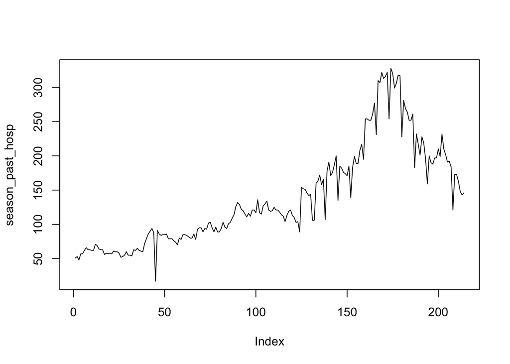

```r
season_past <- seq(as.Date("2021-10-01"),as.Date("2022-05-02"),by="day")
season_past_hosp <- hhs[hhs$state == "TX" & hhs$date %in% season_past,]$total_patients_hospitalized_confirmed_influenza
plot(season_past_hosp,type='l')
```

Now pretend we were sitting at 2022-08-01 and the current season started 2022-07-01. In reality the season would start in October, but we aren’t there yet. Let’s grab the current data.

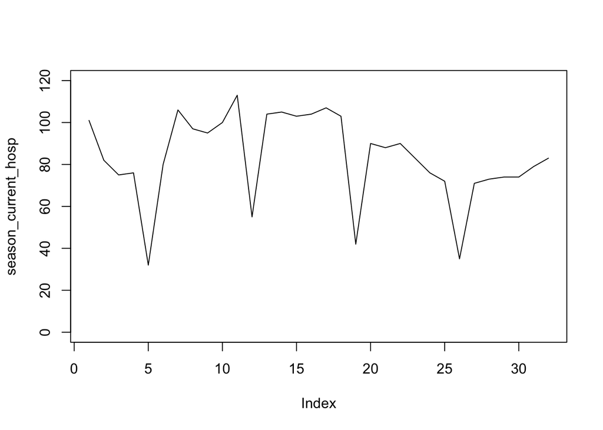

```r
forecast_date <-"2022-08-01"
season_current <- seq(as.Date("2022-07-01"),as.Date(forecast_date),by="day")
season_current_hosp <- hhs[hhs$state == "TX" & hhs$date %in% season_current,]$total_patients_hospitalized_confirmed_influenza
plot(season_current_hosp,type='l',ylim=c(0,120))
```

We are now ready to make a forecast! First we load up semi-mech and pass it the two time series we created. Semi-mech will by default return a 30 day ahead forecast (to match the submission format) in matrix form n_samples x 30 days.

```r
source('semimech.R')
```

```
## Linked to JAGS 4.3.0
```

```
## Loaded modules: basemod,bugs
```

```r
forecast <- run_semi_mech(season_past_hosp = season_past_hosp,season_current_hosp =season_current_hosp )
```

```
## module glm loaded
```

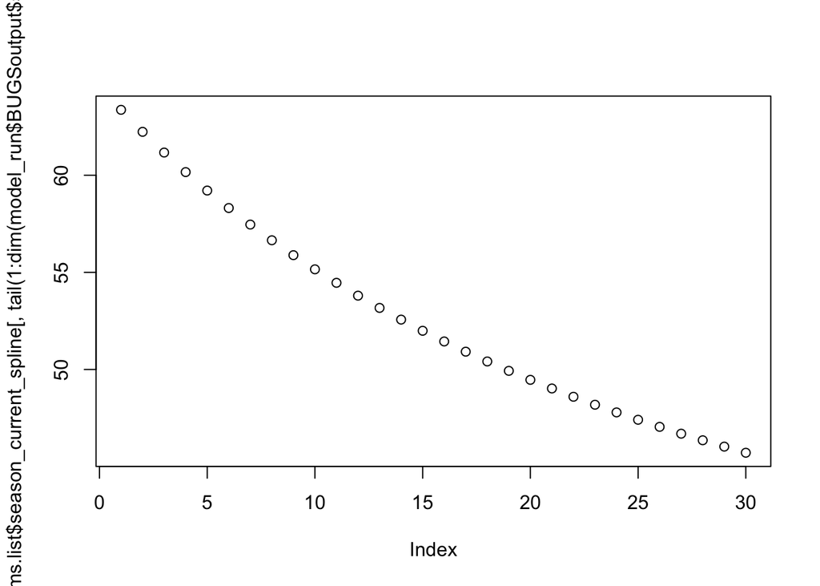

Now we have a forecast object, lets make some plots.

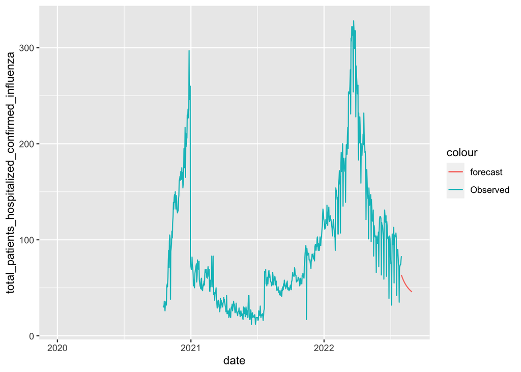

```r
forecast_dates <- seq(as.Date(forecast_date),as.Date(forecast_date)+29,by="day")
forecast_df <- data.frame(date=forecast_dates,total_patients_hospitalized_confirmed_influenza=colMeans(forecast))


ggplot(forecast_df,aes(x=date,y=total_patients_hospitalized_confirmed_influenza,col='forecast')) + geom_line() +
  geom_line(data=hhs[hhs$state == "TX" & hhs$date <= as.Date(forecast_date) ,],aes(x=date,y=total_patients_hospitalized_confirmed_influenza,col='Observed'))
```